# Ejemplo rasteriza

This notebook is going to show how to create a map using geopandas and how to **reduce** the file size of the obtained figure.

```python
import os
import geopandas as gpd
import matplotlib.pyplot as plt
from matplotlib import cm
import warnings
import contextily as ctx
warnings.filterwarnings('ignore')
```

## Create the map

To create the map geopandas already has a implementation to do it, so this example only is going to show a add a map under the the map created in geopandas.

### Load data

The file to be loaded has the job to house ratio in 500 metters. It was created by [pablo](https://github.com/plablo09).

Let us divide the geopandas into 5 different dataframes an plot them each in distinct figures.

```python
entropia_metrop_cdmx_df =gpd.read_file('../data/entropia_manzanas_vecin_500m_2012.zip')
qu = entropia_metrop_cdmx_df['entropia'].quantile(q=[0,.2,.4,.6,.8,1.0])
Q1 = entropia_metrop_cdmx_df[(entropia_metrop_cdmx_df['entropia'] >= qu[0]) & (entropia_metrop_cdmx_df['entropia'] < qu[0.2]) ]
Q2 = entropia_metrop_cdmx_df[(entropia_metrop_cdmx_df['entropia'] >= qu[0.2]) & (entropia_metrop_cdmx_df['entropia'] < qu[0.4]) ]
Q3 = entropia_metrop_cdmx_df[(entropia_metrop_cdmx_df['entropia'] >= qu[0.4]) & (entropia_metrop_cdmx_df['entropia'] < qu[0.6]) ]
Q4 = entropia_metrop_cdmx_df[(entropia_metrop_cdmx_df['entropia'] >= qu[0.6]) & (entropia_metrop_cdmx_df['entropia'] < qu[0.8]) ]
Q5 = entropia_metrop_cdmx_df[(entropia_metrop_cdmx_df['entropia'] >= qu[0.8]) & (entropia_metrop_cdmx_df['entropia'] < qu[1.0]) ]
```

```python
colors=  cm.get_cmap('turbo', 5)
```

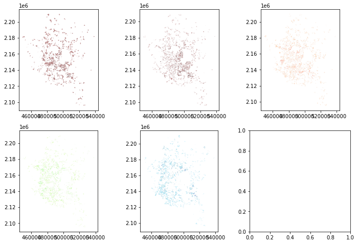

```python
fig, axs = plt.subplots(2,3, figsize=(12, 8))
axs = axs.ravel()

Q1.plot(ax = axs[0], column= 'entropia' , color= colors(5), alpha= .6,  )
Q2.plot(ax = axs[1], column= 'entropia' , color= colors(4), alpha= .5,  )
Q3.plot(ax = axs[2], column= 'entropia' , color= colors(3), alpha= .4,  )
Q4.plot(ax = axs[3], column= 'entropia' , color= colors(2), alpha= .4,  )
Q5.plot(ax = axs[4], column= 'entropia' , color= colors(1), alpha= .4,  )
```

Let us add the streets as background

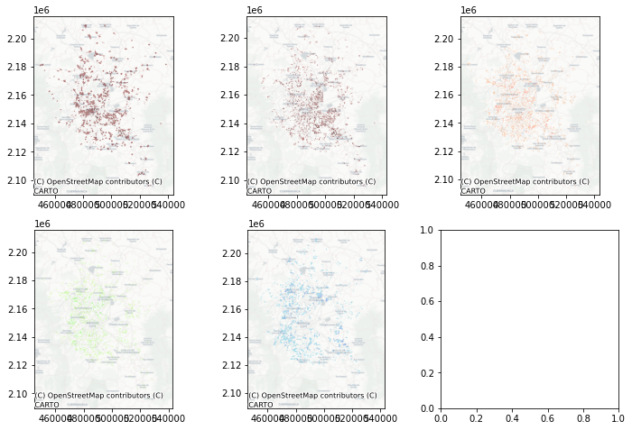

```python
fig, axs = plt.subplots(2,3, figsize=(12, 8))
axs = axs.ravel()

Q1.plot(ax = axs[0], column= 'entropia' , color= colors(5), alpha= .6,  )
Q2.plot(ax = axs[1], column= 'entropia' , color= colors(4), alpha= .5,  )
Q3.plot(ax = axs[2], column= 'entropia' , color= colors(3), alpha= .4,  )
Q4.plot(ax = axs[3], column= 'entropia' , color= colors(2), alpha= .4,  )
Q5.plot(ax = axs[4], column= 'entropia' , color= colors(1), alpha= .4,  )


ctx.add_basemap(axs[0], source=ctx.providers.CartoDB.Positron, crs = Q1.crs)
ctx.add_basemap(axs[1], source=ctx.providers.CartoDB.Positron, crs = Q2.crs)
ctx.add_basemap(axs[2], source=ctx.providers.CartoDB.Positron, crs = Q3.crs)
ctx.add_basemap(axs[3], source=ctx.providers.CartoDB.Positron, crs = Q4.crs)
ctx.add_basemap(axs[4], source=ctx.providers.CartoDB.Positron, crs = Q5.crs)
fig.savefig('../output/test_1.pdf', dpi=600,  bbox_inches='tight')
```

```python
os.path.getsize('../output/test_1.pdf')
```

```
21218249
```

```python
def convert_bytes(size, unit=None):
    if unit == "KB":
        return print('File size: ',  str(round(size / 1024, 3)) ,  ' Kilobytes')
    elif unit == "MB":
        return print('File size: ' + str(round(size / (1024 * 1024), 3)) + ' Megabytes')
    elif unit == "GB":
        return print('File size: ' + str(round(size / (1024 * 1024 * 1024), 3)) + ' Gigabytes')
    else:
        return print('File size: ' + str(size) + ' bytes')
```

```python
bit_size = os.path.getsize('../output/test_1.pdf')
convert_bytes(bit_size,"KB" )
convert_bytes(bit_size,'MB' )
convert_bytes(bit_size,'GB' )
```

```
File size:  20720.946  Kilobytes
File size: 20.235 Megabytes
File size: 0.02 Gigabytes
```

## Ps2pd

As we can see the resulting file size if large, therefore lets reduce the size of it using the ps2pdf tool, this is a fast way to reduce the resulting image but will lose resolution and quality, ps2pdf uses under the hood [ghostscript](https://www.ghostscript.com/) so we can pass the arguments acording to the ghost parammeters here we only will show 1 parameter and the result of it.

```python
! ps2pdf -dPDFSETTINGS=/screen ../output/test_1.pdf ../output/test_1_screen.pdf
```

Sometimes the ps2pdf rotates the image to avoid the rotation use the parameter `-dAutoRotatePages=/None` or if you want to rotate use the correspondig paraameter to do it.

Lets us check how the image was reduce.

```python
bit_size = os.path.getsize('../output/test_1_screen.pdf')
convert_bytes(bit_size,"KB" )
convert_bytes(bit_size,'MB' )
```

```
File size:  9606.604  Kilobytes
File size: 9.381 Megabytes
```

The `-dPDFSETTINGS` parameter has several options but here we only goint to revise the following

- -dPDFSETTINGS=/screen
- -dPDFSETTINGS=/ebook
- -dPDFSETTINGS=/printer
- -dPDFSETTINGS=/prepress
- -dPDFSETTINGS=/default

This options reduce the size of the images the difference between them are the resulting size and quality. The screen reduce the image an leve it optimize for a screeen reolution, the others optimize for *ebook*, *printer*, and *prepress* respectively. The *default* parameter is to be optimize for several devices.

```python
! ps2pdf -dPDFSETTINGS=/ebook ../output/test_1.pdf ../output/test_1_ebook.pdf
! ps2pdf -dPDFSETTINGS=/printer ../output/test_1.pdf ../output/test_1_printer.pdf
! ps2pdf -dPDFSETTINGS=/prepress ../output/test_1.pdf ../output/test_1_prepress.pdf
! ps2pdf -dPDFSETTINGS=/default ../output/test_1.pdf ../output/test_1_default.pdf
```

```python
bit_size = os.path.getsize('../output/test_1_ebook.pdf')
print('ebook')
convert_bytes(bit_size,'MB' )
bit_size = os.path.getsize('../output/test_1_printer.pdf')
print('printer')
convert_bytes(bit_size,'MB' )
bit_size = os.path.getsize('../output/test_1_prepress.pdf')
print('prepress')
convert_bytes(bit_size,'MB' )
bit_size = os.path.getsize('../output/test_1_default.pdf')
print('default')
convert_bytes(bit_size,'MB' )
```

```
ebook
File size: 9.413 Megabytes
printer
File size: 9.662 Megabytes
prepress
File size: 9.845 Megabytes
default
File size: 9.823 Megabytes
```

The reduction of the size will depend on how complicate the original image is. Now to only see a nice map let merge all the maps together.

[figure not shown]

```python
fig, axs = plt.subplots( figsize=(8, 12))
# axs = axs.ravel()

Q1.plot(ax = axs, column= 'entropia' , color= colors(5), alpha= .6,  )
Q2.plot(ax = axs, column= 'entropia' , color= colors(4), alpha= .5,  )
Q3.plot(ax = axs, column= 'entropia' , color= colors(3), alpha= .4,  )
Q4.plot(ax = axs, column= 'entropia' , color= colors(2), alpha= .4,  )
Q5.plot(ax = axs, column= 'entropia' , color= colors(1), alpha= .4,  )

ctx.add_basemap(axs, source=ctx.providers.CartoDB.Positron, crs = Q1.crs)
fig.savefig('../output/test_2.pdf', dpi=600,  bbox_inches='tight')
```

## The matplotlib

[figure not shown]

```python
fig, axs = plt.subplots( figsize=(8, 12))
# axs = axs.ravel()

Q1.plot(ax = axs, column= 'entropia' , color= colors(5), alpha= .5,  rasterized=True)
Q2.plot(ax = axs, column= 'entropia' , color= colors(4), alpha= .5,  rasterized=True)
Q3.plot(ax = axs, column= 'entropia' , color= colors(3), alpha= .5,  rasterized=True)
Q4.plot(ax = axs, column= 'entropia' , color= colors(2), alpha= .5,  rasterized=True)
Q5.plot(ax = axs, column= 'entropia' , color= colors(1), alpha= .5,  rasterized=True)

ctx.add_basemap(axs, source=ctx.providers.CartoDB.Positron, crs = Q1.crs)
fig.savefig('../output/test_3.pdf', dpi=600,  bbox_inches='tight')
```

```python
bit_size = os.path.getsize('../output/test_2.pdf')
print('Non rasterized')
convert_bytes(bit_size,'MB' )

bit_size = os.path.getsize('../output/test_3.pdf')
print('Plot rasterize')
convert_bytes(bit_size,'MB' )
```

```
Non rasterized
File size: 20.741 Megabytes
Plot rasterize
File size: 8.366 Megabytes
```

This only show a simple example on how to rasterize the image there are other approaches to do it, like rasterize for the lowest levels in the matplotlib figure. But I haven't have the need to use such approaches.